# JAGS Notes

## Libraries

```r
library(bayesplot)
```

## Model Background

These notes cover how to implement a bayesian model in the `rjags` package. The examples for these notes come from chapter 8 of [John Kruschke’s book](https://sites.google.com/site/doingbayesiandataanalysis/).

### Bayes’ Formula

As a reminder we will be using `JAGS` to solve a model of the form

$$p(\theta | D) = \frac{p(D|\theta)p(\theta)}{p(D)}$$
where $p(\theta|D)$ is the posterior distribution, $p(D|\theta)$ is the likelihood distribution, $p(\theta)$ is the prior distribution, and $p(D)$ is a normalizing constant.

In the end this formula can be simplified to
$$p(\theta|D) \propto p(D|\theta)p(\theta)$$
.

### Fair Coin

For this problem, we will determine the bias of a coin based on collected coin flip data. To accomplish this in `rjags`, you will need to:

1. Load the data
2. Generate the model
3. Initialize the Markov chains
4. Generate the Markov chains
5. Inspect the Markov chains

#### Load the data

```r
data <- read.csv("2e/z15N50.csv")
y <- data$y
Ntotal <- length(y)
dataList <- list(
  "y" = y,
  "Ntotal" = Ntotal
)
```

#### Generate the model

```r
modelString <- "
  model {
    for(i in 1:Ntotal) {
      y[i] ~ dbern(theta)
    }
    theta ~ dbeta(1, 1)
  }
"

#writeLines(modelString, con = "jags-models/coin-model.txt")
```

#### Initialize the chains

`JAGS` can initalize these values by default, but for large and complex models it is more beneficial to provide a reasonable starting point. For this example, we will use a function that takes a randomized sample of the data and creates a starting point that is approximately equal to the maximum likelihood estimate (MLE).

```r
initsList <- function() {
  resampledY <- sample(y, replace = TRUE)
  thetaInit = sum(resampledY) / length(resampledY)
  thetaInit = 0.001 + 0.998*thetaInit
  return (list(theta=thetaInit))
}
```

#### Generate the chains

```r
jagsModel <- jags.model(
  file = "jags-models/coin-model.txt",
  data = dataList,
  inits = initsList(),
  n.chains = 3, #default is 1
  n.adapt = 500 # default is 1000
)
```

##### Burn-in the model

```r
update(jagsModel, n.iter = 500)
```

[output not shown]

##### Generate Samples

```r
codaSamples <- coda.samples(
  jagsModel,
  variable.names = c("theta"),
  n.iter = 3334
)
```

[output not shown]

#### Inspect the chains

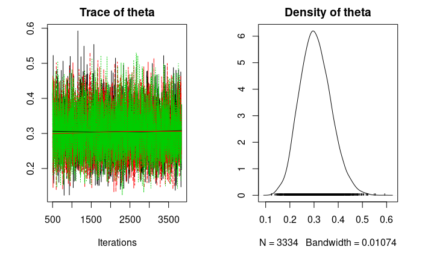

```r
plot(codaSamples)
```

##### View the density plot

```r
plotPost(codaSamples[, "theta"], main = "Theta", xlab=bquote(theta),
         cenTend = "median", compVal = 0.5, ROPE = c(.45, .55),
         credMass = .90)
```

[output not shown]

### Multiple Coins

#### Data

```r
data <- read.csv("2e/z6N8z2N7.csv")
y <- data$y
s <- as.numeric(data$s)
Ntotal <- length(y)
Nsubj <- length(s)
dataList <- list(
  "y" = y,
  "s" = s,
  "Ntotal" = Ntotal,
  "Nsubj" = Nsubj
)
```

#### Model

```r
modelString <- "
  model {
    for(i in 1:Ntotal) {
      y[i] ~ dbern(theta[s])
    }
    for(s in 1:Nsubj){
    theta[s] ~ dbeta(2, 2)
    }
  }
"

#writeLines(modelString, con = "jags-models/two-coins-model.txt")
```

#### Run JAGS

```r
source("2e/Jags-Ydich-XnomSsubj-MbernBeta.R")
#Generate the chain
mcmcCoda <- genMCMC(data = data, numSavedSteps = 10000)
```

#### Diagnostics

```r
plot(mcmcCoda)
```

[output not shown]

#### Summary

```r
smryMCMC(mcmcCoda, compVal = NULL, compValDiff = 0.0)
```

[output not shown]

#### Plot Posterior

```r
plotMCMC(mcmcCoda, data = data, compVal = NULL, compValDiff = 0.0)
```

[output not shown]